# Lab1 Question4

Courtney Miller

2/2/2018

# Table of Contents: “Intro, Summary of Data, Data Analysis, Conclusion.”

## Intro

The dataset *Hollywoood Movies* is from the Lock5Data package. It provides data on movies from Hollywood that were released between the years of 2007 and 2013. Some of the variables included are *Movie* -title of the movie, *RottenTomatoes* - the Rotten Tomatoes score, and *Genre* - the genre of the movie.

```r
 movieDataset <- HollywoodMovies
head(movieDataset)
```

```
##                                       Movie  LeadStudio RottenTomatoes
## 1                              Spider-Man 3        Sony             61
## 2                           Shrek the Third   Paramount             42
## 3                              Transformers   Paramount             57
## 4  Pirates of the Caribbean: At World's End      Disney             45
## 5 Harry Potter and the Order of the Phoenix Warner Bros             78
## 6                               I Am Legend Warner Bros             69
##   AudienceScore         Story     Genre TheatersOpenWeek OpeningWeekend
## 1            54 Metamorphosis    Action             4252          151.1
## 2            57         Quest Animation             4122          121.6
## 3            89 Monster Force    Action             4011           70.5
## 4            74        Rescue    Action             4362          114.7
## 5            82         Quest Adventure             4285           77.1
## 6            69         Quest  Thriller             3606           77.2
##   BOAvgOpenWeekend DomesticGross ForeignGross WorldGross Budget
## 1            35540        336.53       554.34     890.87    258
## 2            29507        322.72       476.24     798.96    160
## 3            17577        319.25       390.46     709.71    150
## 4            26302        309.42       654.00     963.42    300
## 5            17998        292.00       647.88     939.89    150
## 6            21411        256.39       328.96     585.35    150
##   Profitability OpenProfit Year
## 1        345.30      58.57 2007
## 2        499.35      76.00 2007
## 3        473.14      47.00 2007
## 4        321.14      38.23 2007
## 5        626.59      51.40 2007
## 6        390.23      51.47 2007
```

[figure not shown]

This image is from mensxp.com

## Summary of Data

```
##    Min. 1st Qu.  Median    Mean 3rd Qu.    Max.
##    2007    2009    2010    2010    2012    2013
```

```
##    Min. 1st Qu.  Median    Mean 3rd Qu.    Max.    NA's
##    0.00   20.00   35.00   56.12   75.00  300.00      73
```

```
##    Min. 1st Qu.  Median    Mean 3rd Qu.    Max.    NA's
##    0.00   28.00   52.00   51.71   75.00   99.00      57
```

The three variables that I thought would be the most useful are Year - the year the movies were made, Budget- the budget for the movie, RottenTomatoes- the Rotten Tomatoes score for the movie. The summaries for these variables are being displayed in that order.

## Data Analysis

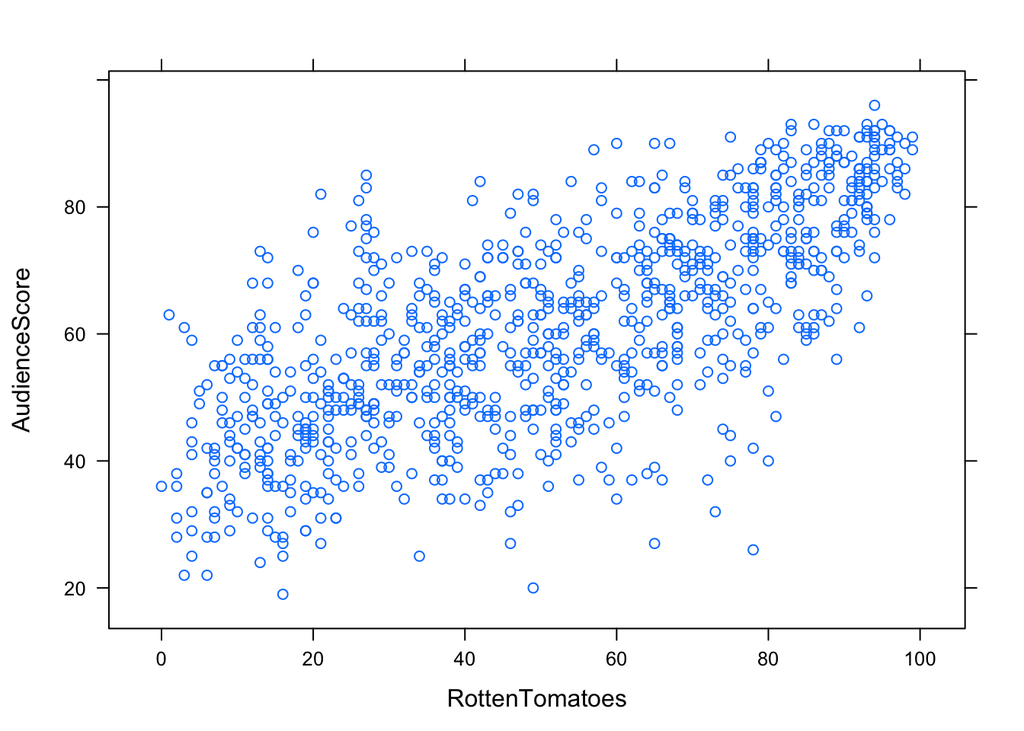

```r
xyplot(AudienceScore ~ RottenTomatoes, data = HollywoodMovies)
```

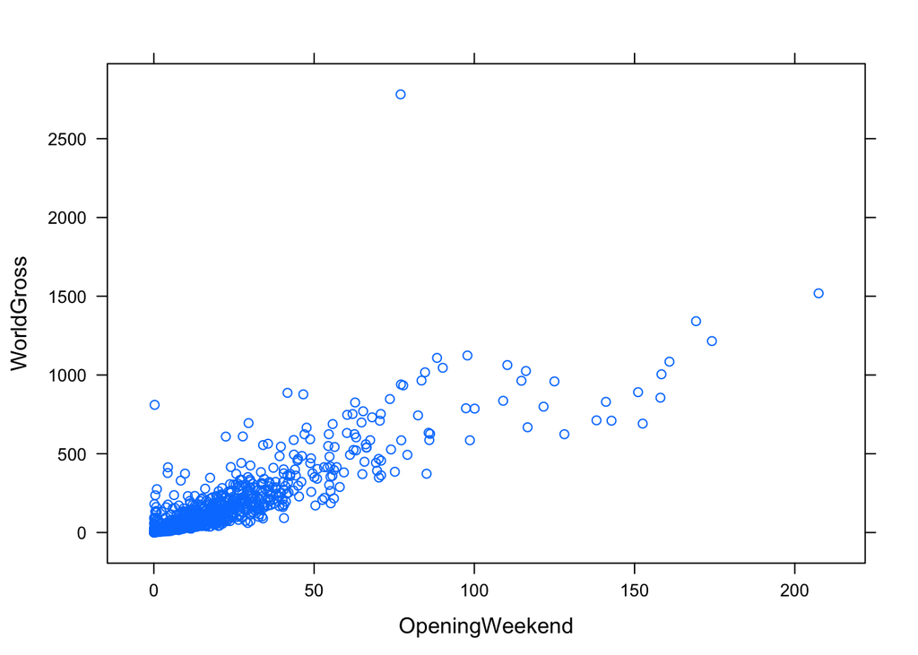

```r
xyplot(WorldGross ~ OpeningWeekend, data = HollywoodMovies)
```

## Conclusion

In the first graph, the audience score is being compared to the Rotten Tomatoes score, to see if theres any type of correlation. And it seems like there is a mild positive correlation between the audience score and the Rotten Tomatoes score.